# Sums of squares

Dr. Brinda

September 23, 2019

## Categorical variable

1. visualize time series
2. scatter plot separated by month
3. scatter plot - log(y) separated by month
4. build categorical design matrix with dummy variables sum of row always=1 every category will have 1 prediction value -> ms <- d1

Recall our airline passenger data.

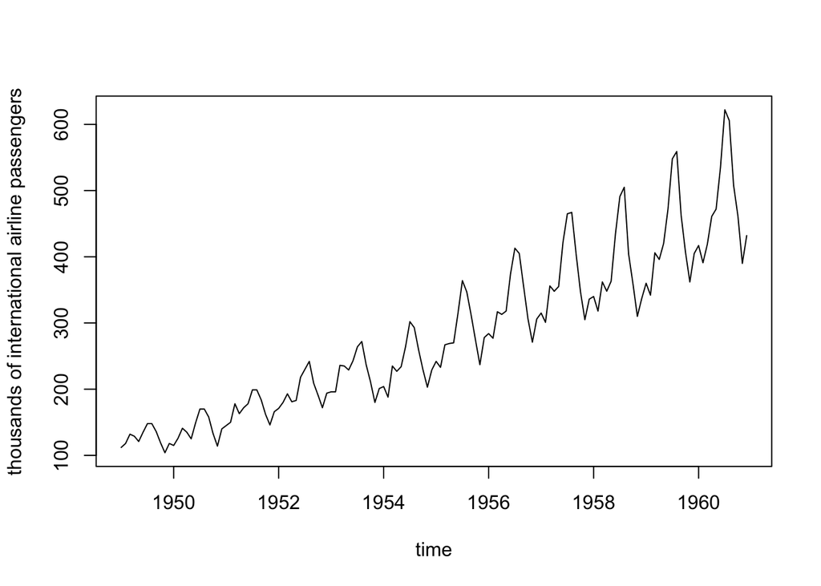

```r
y <- AirPassengers
x <- seq(1949, 1960+11/12, by=1/12)

plot(x, y, type="l", xlab="time", ylab="thousands of international airline passengers")
```

Let’s use this same dataset to explore the use of linear regression for categorical data by considering the months (Jan, Feb, …, Dec) as 12 groups.

```r
# The 12 groups are balanced
y
```

```
##      Jan Feb Mar Apr May Jun Jul Aug Sep Oct Nov Dec
## 1949 112 118 132 129 121 135 148 148 136 119 104 118
## 1950 115 126 141 135 125 149 170 170 158 133 114 140
## 1951 145 150 178 163 172 178 199 199 184 162 146 166
## 1952 171 180 193 181 183 218 230 242 209 191 172 194
## 1953 196 196 236 235 229 243 264 272 237 211 180 201
## 1954 204 188 235 227 234 264 302 293 259 229 203 229
## 1955 242 233 267 269 270 315 364 347 312 274 237 278
## 1956 284 277 317 313 318 374 413 405 355 306 271 306
## 1957 315 301 356 348 355 422 465 467 404 347 305 336
## 1958 340 318 362 348 363 435 491 505 404 359 310 337
## 1959 360 342 406 396 420 472 548 559 463 407 362 405
## 1960 417 391 419 461 472 535 622 606 508 461 390 432
```

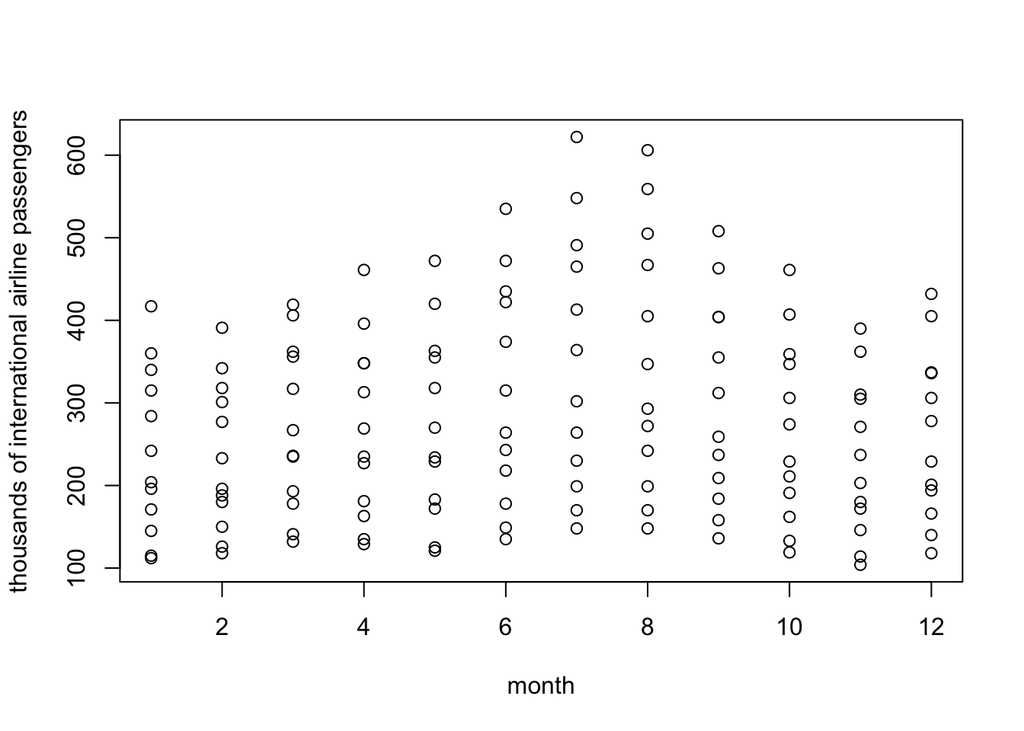

```r
# so the number of observations per group is
n0 <- length(y)/12

plot(rep(1:12, n0), y, xlab="month", ylab="thousands of international airline passengers")
```

Notice that the groups with larger values tend to also have larger variances; this is common and generally undesirable for a variety of reasons, some of which we’ll see in future chapters.

Often a log transformation of the response variable results in groups with more similar variance.

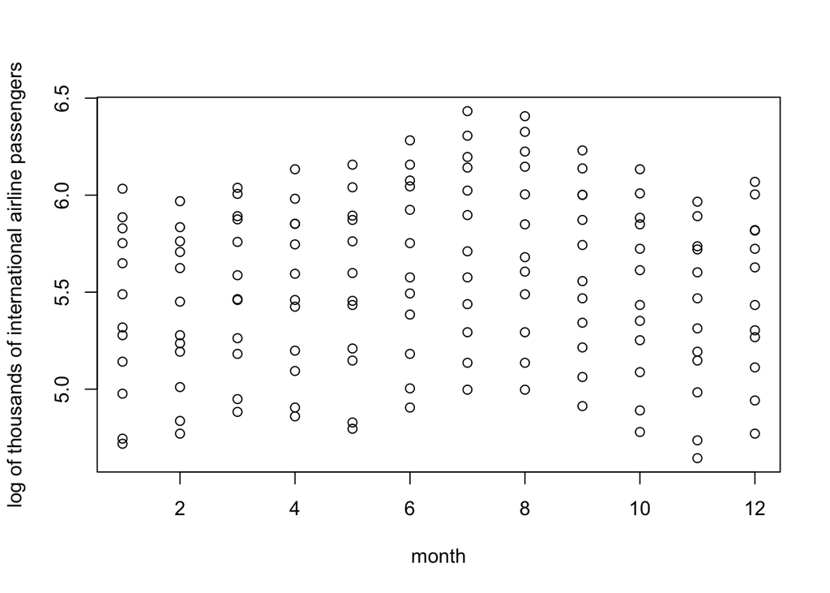

```r
plot(rep(1:12, n0), log(y), xlab="month", ylab="log of thousands of international airline passengers")
```

That’s better. Let’s use $\log(y)$ as our response variable instead.

```r
logy <- log(y)
```

Now I’m going to construct a design matrix then use our least-squares formula to find a coefficient for each group.

```r
jan <- rep(c(1, 0, 0, 0, 0, 0, 0, 0, 0, 0, 0, 0), n0)
feb <- rep(c(0, 1, 0, 0, 0, 0, 0, 0, 0, 0, 0, 0), n0)
mar <- rep(c(0, 0, 1, 0, 0, 0, 0, 0, 0, 0, 0, 0), n0)
apr <- rep(c(0, 0, 0, 1, 0, 0, 0, 0, 0, 0, 0, 0), n0)
may <- rep(c(0, 0, 0, 0, 1, 0, 0, 0, 0, 0, 0, 0), n0)
jun <- rep(c(0, 0, 0, 0, 0, 1, 0, 0, 0, 0, 0, 0), n0)
jul <- rep(c(0, 0, 0, 0, 0, 0, 1, 0, 0, 0, 0, 0), n0)
aug <- rep(c(0, 0, 0, 0, 0, 0, 0, 1, 0, 0, 0, 0), n0)
sep <- rep(c(0, 0, 0, 0, 0, 0, 0, 0, 1, 0, 0, 0), n0)
oct <- rep(c(0, 0, 0, 0, 0, 0, 0, 0, 0, 1, 0, 0), n0)
nov <- rep(c(0, 0, 0, 0, 0, 0, 0, 0, 0, 0, 1, 0), n0)
dec <- rep(c(0, 0, 0, 0, 0, 0, 0, 0, 0, 0, 0, 1), n0)

X <- cbind(jan, feb, mar, apr, may, jun, jul, aug, sep, oct, nov, dec)
ms <- solve(t(X) %*% X) %*% t(X) %*% logy

# the prediction vector cycles through these means each year
logy.hat <- X %*% solve(t(X) %*% X) %*% t(X) %*% logy
```

The least-squares coefficients are exactly the groups’ averages. Let’s add them to our dot plot.

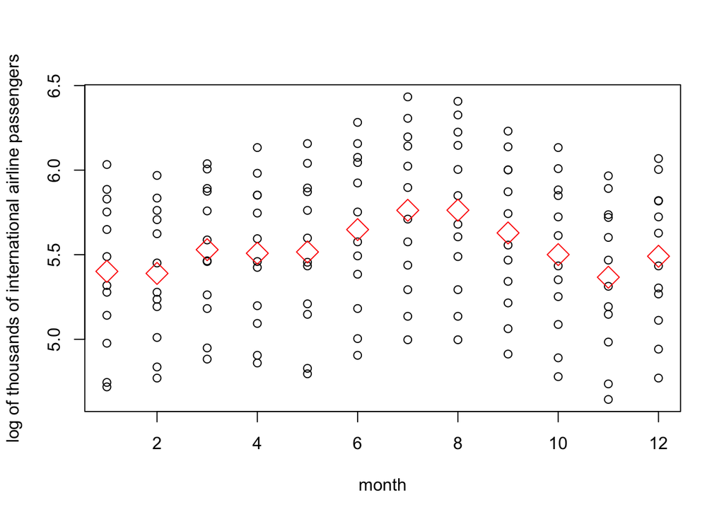

```r
plot(rep(1:12, length(y)/12), logy, xlab="month", ylab="log of thousands of international airline passengers")
points(1:12, ms, col="red", pch=5, cex=2)
```

## Decomposing sums of squares with contrasts

The squared length of the regression vector $\mathbf{\hat{y}} - \mathbf{\bar{y}}$ (aka “regression sum of squares”) is

```r
sum((logy.hat - mean(logy))^2)
```

```
## [1] 2.356056
```

Because the groups are balanced, we can use contrasts to further decompose the regression sum of squares. (For now, the contrasts are just giving us an orthogonal basis for the orthogonal complement of $\mathbf{1}$ in $C(\mathbb{X})$. Later in this course, contrast vectors will be designed with specific interpretations in mind.)

Below, I’ve defined eleven orthogonal contrasts for us.

```r
c1 <- c(1, -1, 0, 0, 0, 0, 0, 0, 0, 0, 0, 0)
c2 <- c(0, 0, 1, -1, 0, 0, 0, 0, 0, 0, 0, 0)
c3 <- c(0, 0, 0, 0, 1, -1, 0, 0, 0, 0, 0, 0)
c4 <- c(0, 0, 0, 0, 0, 0, 1, -1, 0, 0, 0, 0)
c5 <- c(0, 0, 0, 0, 0, 0, 0, 0, 1, -1, 0, 0)
c6 <- c(0, 0, 0, 0, 0, 0, 0, 0, 0, 0, 1, -1)

c7 <- c(1, 1, -1, -1, 0, 0, 0, 0, 0, 0, 0, 0)
c8 <- c(0, 0, 0, 0, 1, 1, -1, -1, 0, 0, 0, 0)
c9 <- c(0, 0, 0, 0, 0, 0, 0, 0, 1, 1, -1, -1)

c10 <- c(1, 1, 1, 1, 0, 0, 0, 0, -1, -1, -1, -1)

c11 <- c(1, 1, 1, 1, -2, -2, -2, -2, 1, 1, 1, 1)

# check that they're orthogonal to each other and to 1
C <- cbind(1, c1, c2, c3, c4, c5, c6, c7, c8, c9, c10, c11)
t(C) %*% C
```

```
##        c1 c2 c3 c4 c5 c6 c7 c8 c9 c10 c11
##     12  0  0  0  0  0  0  0  0  0   0   0
## c1   0  2  0  0  0  0  0  0  0  0   0   0
## c2   0  0  2  0  0  0  0  0  0  0   0   0
## c3   0  0  0  2  0  0  0  0  0  0   0   0
## c4   0  0  0  0  2  0  0  0  0  0   0   0
## c5   0  0  0  0  0  2  0  0  0  0   0   0
## c6   0  0  0  0  0  0  2  0  0  0   0   0
## c7   0  0  0  0  0  0  0  4  0  0   0   0
## c8   0  0  0  0  0  0  0  0  4  0   0   0
## c9   0  0  0  0  0  0  0  0  0  4   0   0
## c10  0  0  0  0  0  0  0  0  0  0   8   0
## c11  0  0  0  0  0  0  0  0  0  0   0  24
```

```r
ms <- solve(t(X) %*% X) %*% t(X) %*% logy
# The corresponding vectors in R^n are, for example,
c1x <- X %*% c1
# but you won't actually need these.
```

### Task 1 (contrasts)

Let’s use the contrast formula that we derived in Monday’s lecture (and at the end of Chapter 2 of the textbook).

```r
squared.coeffs <- rep(0, 11)
for(j in 1:11) {
  contrast <- C[, j+1]
  squared.coeffs[j] <- n0*(contrast%*%ms)^2/sum(contrast^2)
  # CALCULATE THE CONTRASTS' SQUARED COEFFICIENT
  # USING THE FORMULA THAT WE DERIVED IN CLASS (and in the text).
  # IT SHOULD ONLY INVOLVE "contrast" AND "ms" AND "n0".
  # SAVE THE RESULT IN squared.coeffs[j]
}
squared.coeffs
```

```
##  [1] 8.619878e-04 2.696653e-03 1.048848e-01 3.594140e-06 9.844142e-02
##  [6] 9.215752e-02 1.836289e-01 3.909873e-01 2.210609e-01 3.739636e-02
## [11] 1.223936e+00
```

Let’s verify that the sum of these squared coefficients equals the regression sum of squares.

```r
sum(squared.coeffs)
```

```
## [1] 2.356056
```

## Mixing quantitative and categorical variables

The categorical variable for month can capture the seasonal pattern, but it’s missing the overall trend.

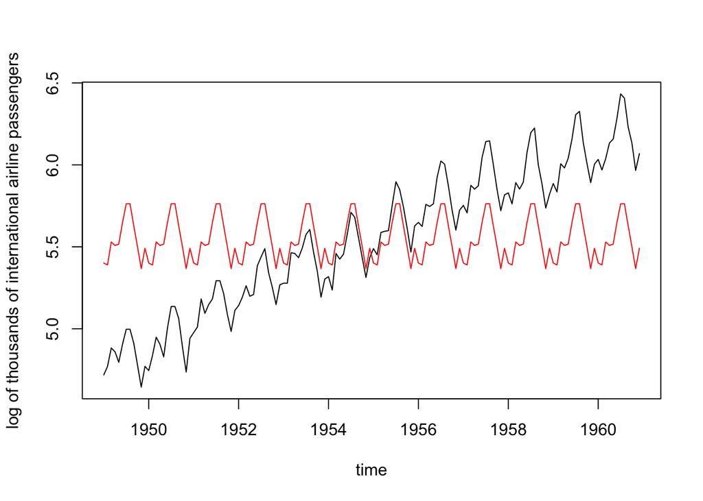

```r
plot(x, logy, type="l", xlab="time", ylab="log of thousands of international airline passengers")
lines(x, logy.hat, col="red")
```

On the other hand, our earlier quadratic fit captured the overall trend but ignored the seasonal pattern. Let’s finally put everything together to fit this data well.

### Task 2 (a design matrix)

Let’s find the least-squares fit for $\log(y)$ that includes a slope for the centered time variable `x - mean(x)` but allows each month to have its own intercept.

In other words, the set of possible fits are functions of the form
$$f(x) = a_1 I(m(x) = \text{Jan}) + a_2 I(m(x) = \text{Feb}) + a_3 I(m(x) = \text{Mar}) + a_4 I(m(x) = \text{Apr}) + a_5 I(m(x) = \text{May}) + a_6 I(m(x) = \text{Jun}) + a_7 I(m(x) = \text{Jul})\\
+ a_8 I(m(x) = \text{Aug}) + a_9 I(m(x) = \text{Sep}) + a_{10} I(m(x) = \text{Oct}) + a_{11} I(m(x) = \text{Nov}) + a_{12} I(m(x) = \text{Dec}) + b_1 (x - \bar{x})$$
where $m(x)$ represents the month and $a_1, \ldots, a_{12}, b_1$ are the free parameters. Because the space of possible fits is linear in the parameters, the least-squares fit coincides with the orthogonal projection and can be found using our usual formulas.

> Define a design matrix `X2` that corresponds to this space of possible fits.

```r
# X2 <- cbind( FIGURE OUT WHAT TO PUT IN HERE )

# PLACEHOLDER, JUST SO THAT YOU WON'T HAVE
# KNITTING ERRORS BEFORE YOU GET TO THIS PART:
X2 <- cbind(jan, feb, mar, apr, may, jun, jul, aug, sep, oct, nov, dec,x - mean(x))
# MAKE SURE TO DELETE THIS WHEN YOU DEFINE THE REAL X2
```

Below, I’ve calculated the resulting least-squares predicted values to see how well they match the data.

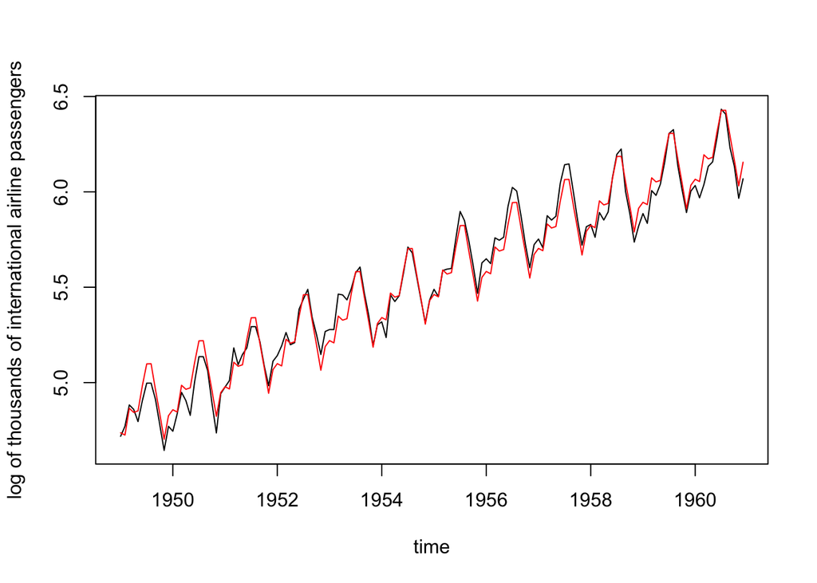

```r
logy.hat2 <- X2 %*% solve(t(X2) %*% X2) %*% t(X2) %*% logy

plot(x, logy, type="l", xlab="time", ylab="log of thousands of international airline passengers")
lines(x, logy.hat2, col="red")
```

### Task 3 (another design matrix)

Let’s find the least-squares fit for $\log(y)$ that includes a quadratic fit with the centered time variable `x - mean(x)` but allows each month to have its own intercept.

In other words, the set of possible fits are functions of the form
$$f(x) = a_1 I(m(x) = \text{Jan}) + a_2 I(m(x) = \text{Feb}) + a_3 I(m(x) = \text{Mar}) + a_4 I(m(x) = \text{Apr}) + a_5 I(m(x) = \text{May}) + a_6 I(m(x) = \text{Jun}) + a_7 I(m(x) = \text{Jul})\\
+ a_8 I(m(x) = \text{Aug}) + a_9 I(m(x) = \text{Sep}) + a_{10} I(m(x) = \text{Oct}) + a_{11} I(m(x) = \text{Nov}) + a_{12} I(m(x) = \text{Dec}) + b_1 (x - \bar{x}) + b_2 (x - \bar{x})^2.$$

> Define a design matrix `X3` that corresponds to this space of possible fits.

```r
# X3 <- cbind( FIGURE OUT WHAT TO PUT IN HERE )


# PLACEHOLDER, JUST SO THAT YOU WON'T HAVE
# KNITTING ERRORS BEFORE YOU GET TO THIS PART:
X3 <- cbind(jan, feb, mar, apr, may, jun, jul, aug, sep, oct, nov, dec,x - mean(x), (x - mean(x))^2)
# MAKE SURE TO DELETE THIS WHEN YOU DEFINE THE REAL X3
```

Below, you’ll see how well the resulting least-squares predicted values match the data.

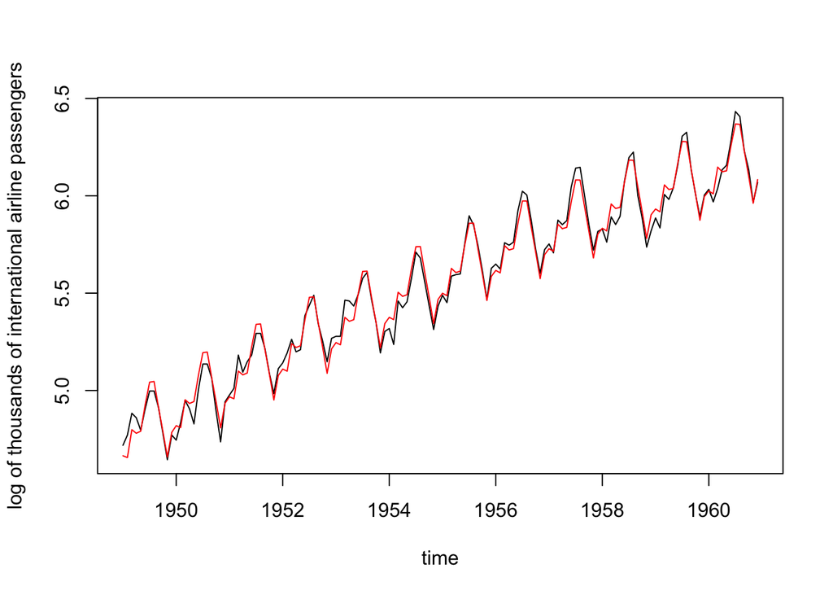

```r
logy.hat3 <- X3 %*% solve(t(X3) %*% X3) %*% t(X3) %*% logy

plot(x, logy, type="l", xlab="time", ylab="log of thousands of international airline passengers")
lines(x, logy.hat3, col="red")
```